# Text Analysis

a guidone

April 22, 2017

From 1824-1825 General Lafayette toured all twenty-four American states on a welcome tour and celebration of the fiftieth anniversary of the American Revolution. Originally invited by President Monroe, Lafayette was welcomed throughout America by an exuberant populace, enthusiastic press, and fawning politicians. This text analysis operates on roughly 525 pages of combined newspaper clippings covering Lafayette’s return tour.[^1] The text mostly traced his travels, described welcome celebrations, gave parade details, and also printed welcome speeches and at times Lafayette’s response. There is some editorial filler between newspapers and in endnotes but this is dwarfed by the primary source content.

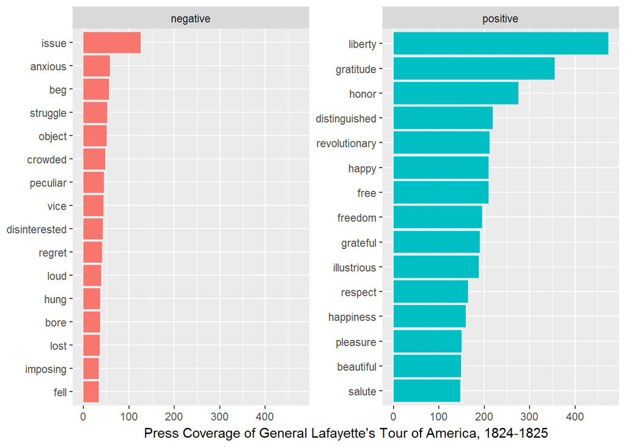

In the following graph we can see just how infrequent negative words appeared in press coverage of Lafayette.

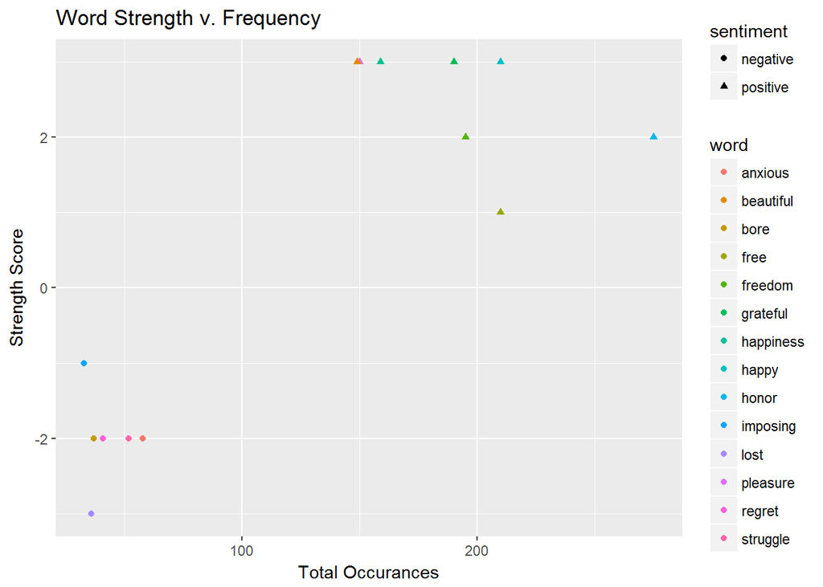

Only one word, “lost”, has a negativity strength of -3 whereas there are 5 positive words with a +3 positivity ranking. Additionally, it also makes clear the discrepancy in how often these words were used throughout newspapers. All the negative words are concentrated to the left of the graph whereas the positive words are on the far right.

The next visualization is a topic modeling program which will show group words together based on what it perceives as similar topics. Then, I can use the paragraphs flagged as containing those topics to investigate more about them. I selected 5 topics and the top 10 words used in these are seen below.

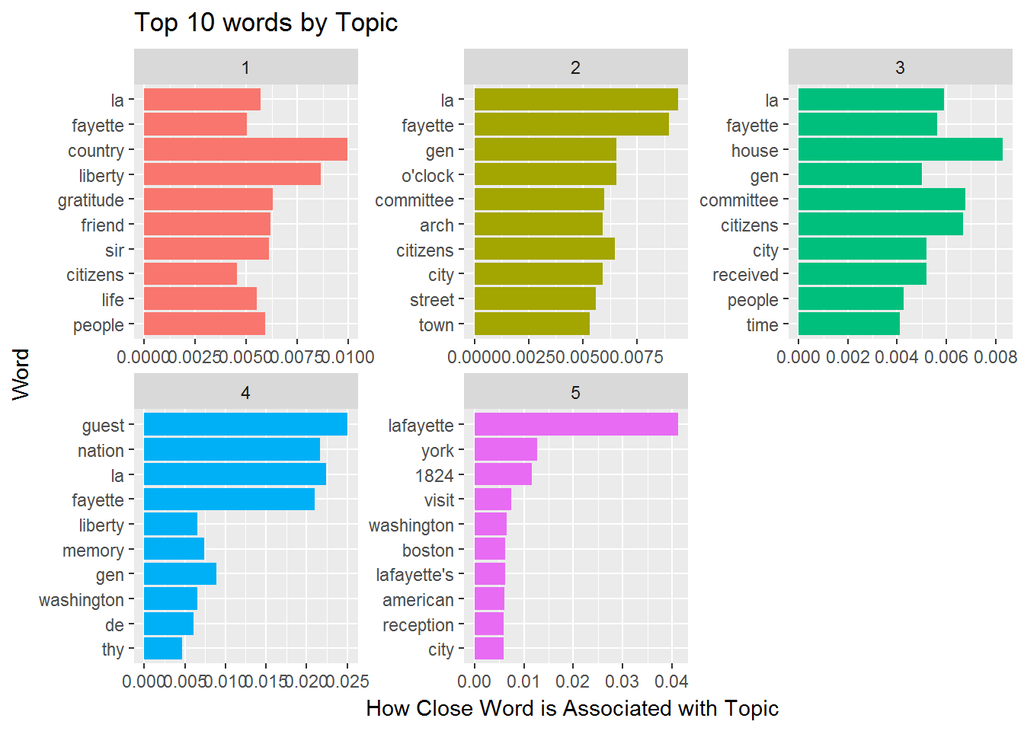

The program did well at picking out topic 2 as that seems to be describing celebrations. In my research I was looking at celebrations and parades so I would start by reading all of those paragraphs which contain topic 2 (and possibly topic 3 as well).

[^1]: the text is taken from vol. I, II, and III of Lafayette: Guest of the Nation, a Contemporary Account of the Triumphal Tour of General Lafayette edited by Edgar E. Brandon.